# Plot Guide

GEOG-490R

Spring 2024

## Introduction to Data Visualization in R

Below are a few examples of how to create basic graphs in R using the built-in graphics capabilities. We will use the `mtcars` dataset that comes with R.

### Loading the mtcars dataset

The `mtcars` dataset contains fuel economy data for 32 cars. Let’s load it into R:

```r
data(mtcars)
```

### Scatterplot

A scatterplot can be used to visualize the relationship between two continuous variables. Let’s plot mileage (mpg) vs horsepower (hp):

```r
plot(mtcars$hp, mtcars$mpg)
```

You can alter the point type of a scatterplot using the `pch` argument.

We should also add axis labels, a title, and customize other elements:

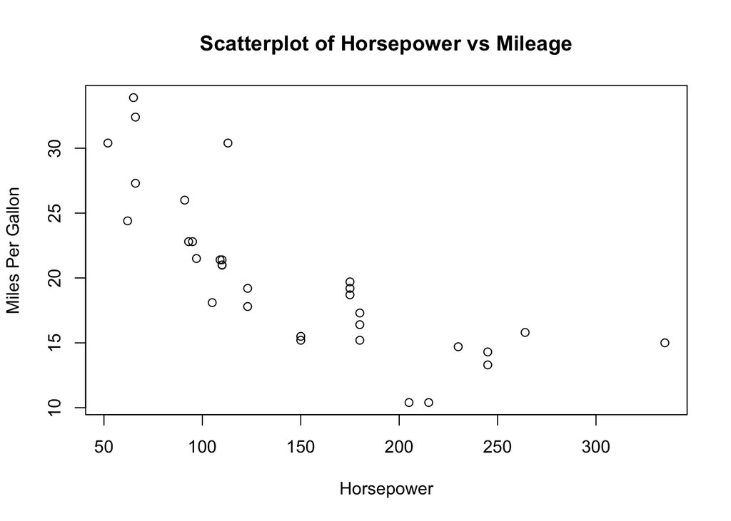

```r
plot(mtcars$hp, mtcars$mpg,
     main="Scatterplot of Horsepower vs Mileage",
     xlab="Horsepower", ylab="Miles Per Gallon")
```

lines can also be added to plots

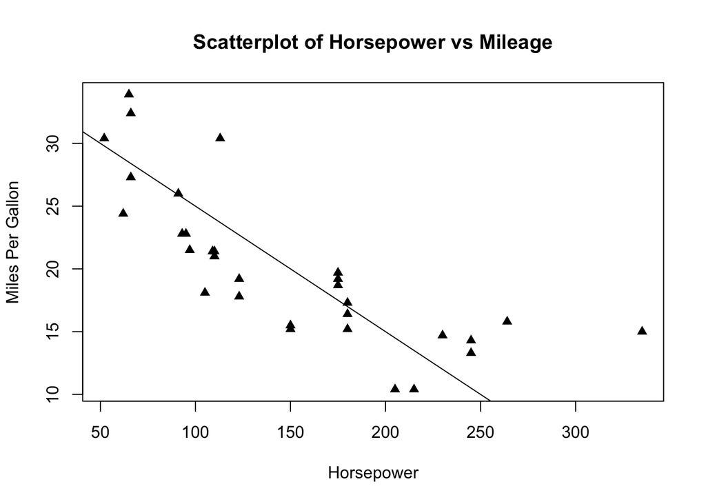

```r
plot(mtcars$hp, mtcars$mpg, pch = 17,
     main="Scatterplot of Horsepower vs Mileage",
     xlab="Horsepower", ylab="Miles Per Gallon")
abline(a = 35, b = -0.1) # intercept and slope
```

The `abline` function will also accept model outputs and objects that contain the required coefficients.

### Histogram

A histogram shows the distribution of a continuous variable. We can use `hist()` to plot a histogram of the mpg values:

```r
hist(mtcars$mpg)
```

Customize the number of bins, add labels and title:

```r
hist(mtcars$mpg, breaks=15,
     main="Histogram of Mileage",
     xlab="Miles Per Gallon")
```

### Boxplot

A boxplot visualizes numeric data by quartiles. Let’s make a boxplot of mpg by number of cylinders:

```r
boxplot(mpg ~ cyl, data=mtcars)
```

Add axis labels:

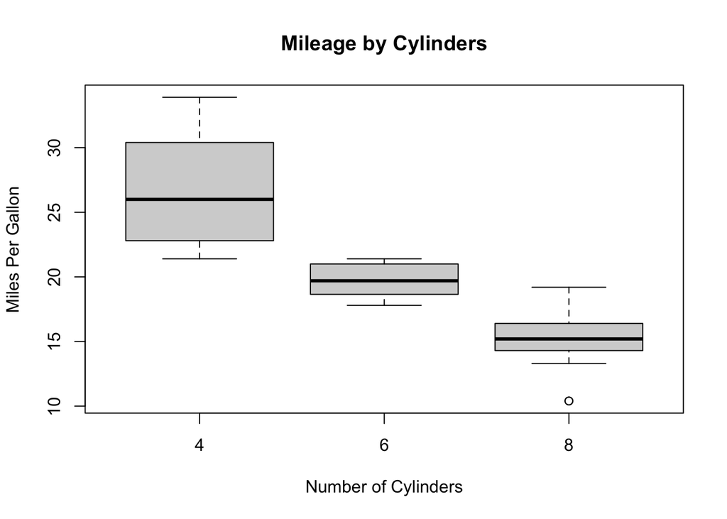

```r
boxplot(mpg ~ cyl, data=mtcars,
        main="Mileage by Cylinders",
        xlab="Number of Cylinders",
        ylab="Miles Per Gallon")
```

### Bar Plot

Use a barplot to compare numeric values across categories:

```r
barplot(table(mtcars$cyl))
```

Customize with axis labels, title, legend:

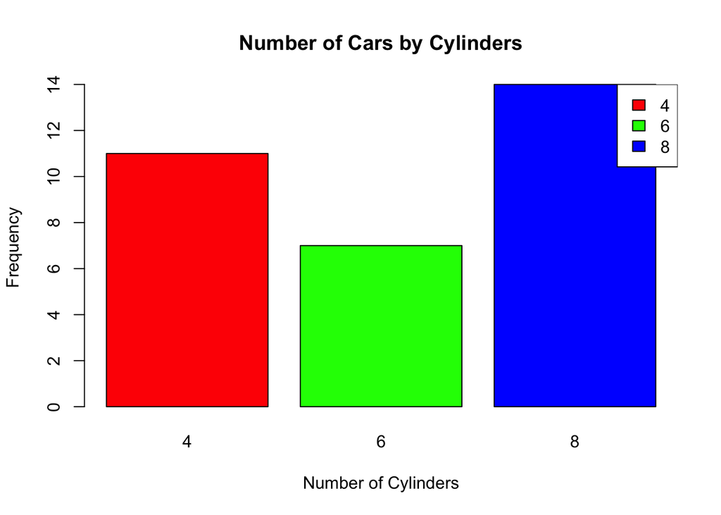

```r
barplot(table(mtcars$cyl),
        main="Number of Cars by Cylinders",
        xlab="Number of Cylinders",
        ylab="Frequency", col=c("red","green","blue"))
legend("topright", legend=c("4", "6", "8"), fill=c("red","green","blue"))
```

### Pie Chart

A pie chart shows proportional values as slices of a pie. We can use `pie()` to plot a pie chart of the number of cars by cylinder:

```r
pie(table(mtcars$cyl),
    labels = c("4 cyl", "6 cyl", "8 cyl"),
    main="Cars by Cylinders")
```

Add a legend:

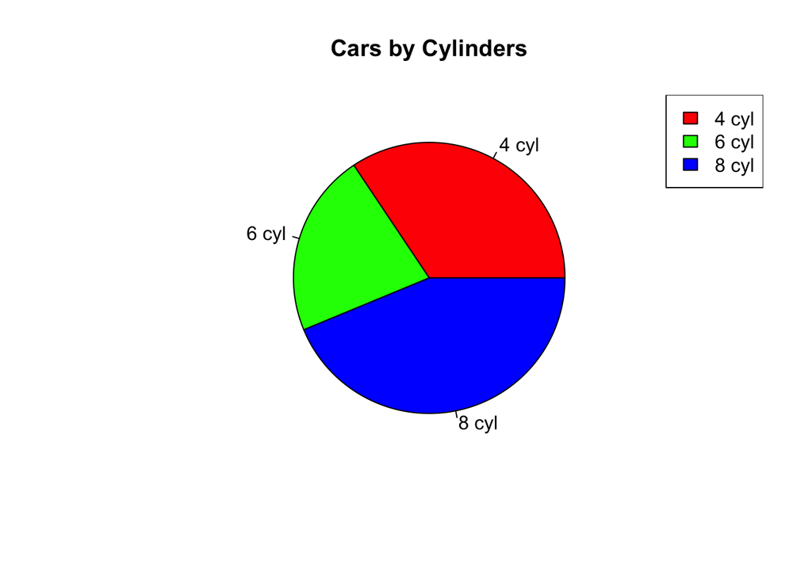

```r
pie(table(mtcars$cyl),
    labels = c("4 cyl", "6 cyl", "8 cyl"),
    col=c("red","green","blue"),
    main="Cars by Cylinders")
legend("topright", c("4 cyl", "6 cyl", "8 cyl"), fill=c("red", "green", "blue"))
```

The pie chart allows us to easily visualize the proportions for each cylinder category.

In general, I would say that pie plots are bar plots are the least useful type of plot, there is typically a better way to show the information. However, in some instances, this can be the perfect type of visualization.